# Advanced search and citation of occurrences

Hannah L. Owens

Cory Merow

Brian Maitner

Jamie M. Kass

Vijay Barve

Robert Guralnick

2022-02-28

# Advanced features

This vignette demonstrates more advanced features and customization available in `occCite`. We recommend you read `vignette("Simple.Rmd", package = "occCite")` first, if you have not already done so.

## Loading data from previous GBIF searches

```r
# Simple load
myOldOccCiteObject <- occQuery(x = "Protea cynaroides",
                                  datasources = c("gbif", "bien"),
                                  GBIFLogin = NULL,
                                  GBIFDownloadDirectory = system.file('extdata/', package='occCite'),
                                  loadLocalGBIFDownload = T,
                                  checkPreviousGBIFDownload = F)
```

Here is the result. Look familiar?

```r
#GBIF search results
head(myOldOccCiteObject@occResults$`Protea cynaroides`$GBIF$OccurrenceTable);
```

```
##                name longitude  latitude day month year
## 1 Protea cynaroides  18.93389 -34.34556  30     7 1996
## 2 Protea cynaroides   7.58091  48.03637   1    12 2021
## 3 Protea cynaroides  22.46342 -33.97392  10    11 2021
## 4 Protea cynaroides  25.21399 -33.90482   3    10 2021
## 5 Protea cynaroides  23.11940 -34.07554   1    11 2021
## 6 Protea cynaroides  19.07559 -33.02624  21    11 2021
##                                   Dataset                           DatasetKey
## 1          BODATSA: Botanical Collections d0963cee-1a29-47a2-b9bf-fb0e7690077c
## 2                             naturgucker 6ac3f774-d9fb-4796-b3e9-92bf6c81c084
## 3 iNaturalist Research-grade Observations 50c9509d-22c7-4a22-a47d-8c48425ef4a7
## 4 iNaturalist Research-grade Observations 50c9509d-22c7-4a22-a47d-8c48425ef4a7
## 5 iNaturalist Research-grade Observations 50c9509d-22c7-4a22-a47d-8c48425ef4a7
## 6 iNaturalist Research-grade Observations 50c9509d-22c7-4a22-a47d-8c48425ef4a7
##   DataService
## 1        GBIF
## 2        GBIF
## 3        GBIF
## 4        GBIF
## 5        GBIF
## 6        GBIF
```

```r
#The full summary
summary(myOldOccCiteObject)
```

```
##
##  OccCite query occurred on: 28 February, 2022
##
##  User query type: User-supplied list of taxa.
##
##  Sources for taxonomic rectification: GBIF Backbone Taxonomy
##
##
##  Taxonomic cleaning results:
##
##          Input Name                        Best Match
## 1 Protea cynaroides Protea cynaroides (L.) L. L. (L.)
##   Taxonomic Databases w/ Matches
## 1         GBIF Backbone Taxonomy
##
##  Sources for occurrence data: gbif, bien
##
##                             Species Occurrences Sources
## 1 Protea cynaroides (L.) L. L. (L.)        2266      17
##
##  GBIF dataset DOIs:
##
##                             Species GBIF Access Date           GBIF DOI
## 1 Protea cynaroides (L.) L. L. (L.)       2022-01-13 10.15468/dl.tuzxby
```

Getting citation data works the exact same way with previously-downloaded data as it does from a fresh data set.

```r
#Get citations
myOldOccCitations <- occCitation(myOldOccCiteObject)
print(myOldOccCitations)
```

[output not shown]

Note that you can also load multiple species using either a vector of species names or a phylogeny (provided you have previously downloaded data for all of the species of interest), and you can load occurrences from non-GBIF data sources (e.g. BIEN) in the same query.

## Performing a Multi-Species Search

In addition to doing a simple, single species search, you can also use `occCite` to search for and manage occurrence datasets for multiple species. You can either submit a vector of species names, or you can submit a *phylogeny*! The occCitation function will return a named list of citation tables in the case of multiple species.

## occCite with a Phylogeny

Here is an example of how such a search is structured, using an unpublished phylogeny of billfishes.

```r
library(ape)
#Get tree
treeFile <- system.file("extdata/Fish_12Tax_time_calibrated.tre", package='occCite')
phylogeny <- ape::read.nexus(treeFile)
tree <- ape::extract.clade(phylogeny, 22)
#Query databases for names
myPhyOccCiteObject <- studyTaxonList(x = tree,
                                     datasources = "GBIF Backbone Taxonomy")
#Query GBIF for occurrence data
myPhyOccCiteObject <- occQuery(x = myPhyOccCiteObject,
                            datasources = "gbif",
                            GBIFDownloadDirectory = system.file('extdata/', package='occCite'),
                            loadLocalGBIFDownload = T,
                            checkPreviousGBIFDownload = F)
# What does a multispecies query look like?
summary(myPhyOccCiteObject)
```

```
##
##  OccCite query occurred on: 28 February, 2022
##
##  User query type: User-supplied phylogeny.
##
##  Sources for taxonomic rectification: GBIF Backbone Taxonomy
##
##
##  Taxonomic cleaning results:
##
##                   Input Name                                    Best Match
## 1 Tetrapturus_angustirostris       Tetrapturus angustirostris Tanaka, 1915
## 2         Tetrapturus_belone           Tetrapturus belone Rafinesque, 1810
## 3      Tetrapturus_pfluegeri Tetrapturus pfluegeri Robins & de Sylva, 1963
##   Taxonomic Databases w/ Matches
## 1         GBIF Backbone Taxonomy
## 2         GBIF Backbone Taxonomy
## 3         GBIF Backbone Taxonomy
##
##  Sources for occurrence data: gbif
##
##                                         Species Occurrences Sources
## 1       Tetrapturus angustirostris Tanaka, 1915         649      23
## 2           Tetrapturus belone Rafinesque, 1810           9       6
## 3 Tetrapturus pfluegeri Robins & de Sylva, 1963         410       8
##
##  GBIF dataset DOIs:
##
##                                         Species GBIF Access Date
## 1       Tetrapturus angustirostris Tanaka, 1915       2019-07-04
## 2           Tetrapturus belone Rafinesque, 1810       2019-07-04
## 3 Tetrapturus pfluegeri Robins & de Sylva, 1963       2019-07-04
##             GBIF DOI
## 1 10.15468/dl.mumi5e
## 2 10.15468/dl.q2nxb1
## 3 10.15468/dl.qjidbs
```

When you have results for multiple species, as in this case, you can also plot the summary figures either for the whole search…

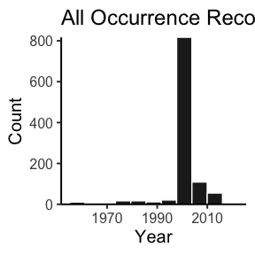

[figure not shown]

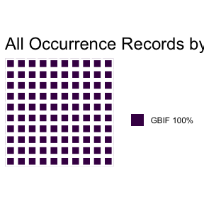

```r
plot(myPhyOccCiteObject)
```

*or* you can plot the results by species!

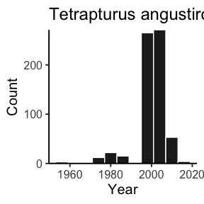

[figure not shown]

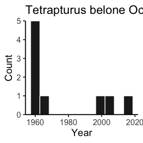

[figure not shown]

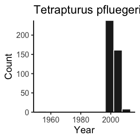

[figure not shown]

```r
plot(myPhyOccCiteObject, bySpecies = T, plotTypes = c("yearHistogram", "source"))
```

And then you can print out the citations, separated by species (or not, but in this example, they’re separate).

```r
#Get citations
myPhyOccCitations <- occCitation(myPhyOccCiteObject)

#Print citations as text with accession dates.
print(myPhyOccCitations, bySpecies = T)
```

[output not shown]